# Markets and Models

Comparing 2018 Midterm Predictions

Kiernan Nicholls

May 07, 2019

## 0.1 Overview

The forecast model has become a staple of political punditry in recent years. Popularized by the data journalism site [FiveThirtyEight](https://fivethirtyeight.com/), the forecasting model is a statistical tool used to incorporate a number of quantitative inputs to generate a *probabilistic* view of all possible outcomes.

Prediction markets can be used as alternative method of generating similarly probabilistic views of election outcomes. Markets utilize the economic forces of price discovery and risk aversion to overcome the ideological bias of self-interested traders on a binary options exchange.

Can markets help us predict elections better than the models? If so, under what conditions?

I propose a null hypothesis of no difference between the proportion of accurate predictions made by forecasting models and prediction markets in the 2018 congressional midterm elections.

## 0.2 Reproduce

All data used in this project is freely available for academic research. An archived version of all public information has been created on the free Internet Archive.

Additionally, the source code for this summary, a [more detailed academic manuscript](https://github.com/kiernann/predictr/blob/master/docs/paper/paper.pdf), and [all analysis](https://github.com/kiernann/predictr/tree/master/code) is hosted on a [public GitHub repository](https://github.com/kiernann/predictr), which can be cloned to reproduce findings exactly. All software needed to produce the same results is free and open source.

### 0.2.1 Packages

All data sets is collected, formatted, combined, and analyzed using the statistical computing language R (R Core Team 2018a) and a handful of specialized packages, mostly from the [tidyverse](https://www.tidyverse.org/) ecosystem.

```r
library(devtools) # for package managment
install_cran("here") # for local storage
install_cran("tidyverse") # for data manipulation
install_cran("verification") # for forecast analysis
install_github("hrbrmstr/wayback") # for internet archives
```

```r
library(readr)     # reading data
library(dplyr)     # wrangling data
library(tidyr)     # tidying data
library(knitr)     # pritning tables
library(tibble)    # rectangle data
library(pander)    # printing tests
library(stringr)   # character strings
library(wayback)   # reading archives
library(ggplot2)   # plotting data
library(magrittr)  # piping data
library(lubridate) # dates strings
```

### 0.2.2 Read Data

Reading data is handles by the `readr` (Wickham, Hester, and Francois 2018) and `wayback` (Rudis 2017) packages. Data public on the Internet has been archived for posterity and stored as “mementos” accessible by the [Wayback Machine](https://archive.org/web/). Data is read as a raw file and formatted by `read_delim()`.

#### 0.2.2.1 Read Markets

Market data is courtesy of PredictIt.org, an exchange owned and operated by the Victoria University of Wellington, New Zealand. The past 90 days of all market data can be scraped, but more in depth data is provided to partnered academic researchers. The data for this project can be found in the `/data` directory of the GitHub repository.

```r
DailyMarketData <-
  here::here("data", "DailyMarketData.csv") %>%
  read_delim(delim = "|",
             na = "n/a",
             col_types = cols(
               MarketId = col_character(),
               ContractName = col_character(),
               ContractSymbol = col_character(),
               Date = col_date(format = "")))

Market_ME02 <-
  here::here("data", "Market_ME02.csv") %>%
  read_csv(col_types = cols(ContractID = col_character(),
                            Date = col_date(format = "%m/%d/%Y")))

Contract_NY27 <-
  here::here("data" , "Contract_NY27.csv") %>%
  read_csv(na = c("n/a", "NA"),
           skip = 156,
           col_types = cols(ContractID = col_character(),
                            Date = col_date(format = "%m/%d/%Y")))
```

Input Market Data (Sample)

| MarketSymbol | ContractSymbol | Date | OpenPrice | ClosePrice | Volume |
| --- | --- | --- | --- | --- | --- |
| TX21.2018 | GOP.TX21.2018 | 2017-11-20 | 0.70 | 0.70 | 3 |
| PA15.2018 | DEM.PA15.2018 | 2017-12-22 | 0.43 | 0.43 | 0 |
| NH01.2018 | DEM.NH01.2018 | 2018-05-19 | 0.83 | 0.83 | 0 |
| NV04.2018 | GOP.NV04.2018 | 2018-07-13 | 0.27 | 0.27 | 0 |
| FL15.2018 | GOP.FL15.2018 | 2018-08-28 | 0.74 | 0.74 | 5 |
| COMS.VA10.2018 | NA | 2018-09-08 | 0.14 | 0.14 | 50 |
| NC13.2018 | GOP.NC13.2018 | 2018-09-08 | 0.58 | 0.58 | 0 |
| CURB.FL26.2018 | NA | 2018-10-13 | 0.60 | 0.59 | 44 |
| CURB.FL26.2018 | NA | 2018-10-24 | 0.61 | 0.59 | 155 |
| NC09.2018 | GOP.NC09.2018 | 2018-11-04 | 0.51 | 0.50 | 16 |

#### 0.2.2.2 Read Members

```r
## Current members of the 115th
## Archived: 2018-10-22 at 18:11
  legislators_current <-
  "https://theunitedstates.io/congress-legislators/legislators-current.csv" %>%
  read_memento(timestamp = "2018-10-22", as = "raw") %>%
  read_csv(col_types = cols(govtrack_id = col_character()))

# The ideology and leadership scores of the 115th
# Calculated with cosponsorship analysis
# Archived 2019-01-21 17:13:08
sponsorshipanalysis_h <-
  str_c("https://www.govtrack.us/",
        "data/analysis/by-congress/115/sponsorshipanalysis_h.txt") %>%
  read_memento(timestamp = "2019-03-23", as = "raw") %>%
  read_csv(col_types = cols(ID = col_character()))

sponsorshipanalysis_s <-
  str_c("https://www.govtrack.us/",
        "data/analysis/by-congress/115/sponsorshipanalysis_s.txt") %>%
  read_memento(timestamp = "2019-03-23", as = "raw") %>%
  read_csv(col_types = cols(ID = col_character()))
```

Input Member Data (Sample)

| last_name | birthday | gender | type | state | district | party |
| --- | --- | --- | --- | --- | --- | --- |
| Bucshon | 1962-05-31 | M | rep | IN | 8 | Republican |
| Crowley | 1962-03-16 | M | rep | NY | 14 | Democrat |
| DeLauro | 1943-03-02 | F | rep | CT | 3 | Democrat |
| Engel | 1947-02-18 | M | rep | NY | 16 | Democrat |
| Frelinghuysen | 1946-04-29 | M | rep | NJ | 11 | Republican |
| Hill | 1956-12-05 | M | rep | AR | 2 | Republican |
| Kennedy | 1980-10-04 | M | rep | MA | 4 | Democrat |
| Kustoff | 1966-10-08 | M | rep | TN | 8 | Republican |
| Luján | 1972-06-07 | M | rep | NM | 3 | Democrat |
| Pittenger | 1948-08-15 | M | rep | NC | 9 | Republican |

#### 0.2.2.3 Read Models

While the FiveThirtyEight model proprietary, they release top level output data free to the public as two separate files, one for the House (FiveThirtyEight 2018a) and one for the Senate (FiveThirtyEight 2018b).

```r
## District level 538 House model history
## Updated:  2018-11-06 at 01:56
## Archived: 2018-11-06 at 12:06
house_district_forecast <-
  str_c(site = "https://projects.fivethirtyeight.com/",
        file = "congress-model-2018/house_district_forecast.csv") %>%
  read_memento(timestamp = "2018-11-06", as = "raw") %>%
  read_csv()

# Seat level 538 Senate model history
# Updated:  2018-11-06 at 11:06
# Archived: 2018-11-06 at 21:00
senate_seat_forecast <-
  str_c(site = "https://projects.fivethirtyeight.com/",
        file = "congress-model-2018/senate_seat_forecast.csv") %>%
  read_memento(timestamp = "2018-11-06", as = "raw") %>%
  read_csv()
```

Input House Model Data (Sample)

| forecastdate | state | district | party | incumbent | win_probability | voteshare |
| --- | --- | --- | --- | --- | --- | --- |
| 2018-08-11 | LA | 6 | I | FALSE | 0.000 | 2.51 |
| 2018-08-22 | PA | 2 | D | TRUE | 1.000 | 78.22 |
| 2018-08-23 | MI | 5 | R | FALSE | 0.001 | 33.17 |
| 2018-09-05 | FL | 9 | D | TRUE | 0.999 | 64.45 |
| 2018-09-12 | WI | 3 | D | TRUE | 0.996 | 62.11 |
| 2018-09-17 | IL | 12 | GRE | FALSE | 0.000 | 3.15 |
| 2018-10-02 | NC | 2 | D | FALSE | 0.356 | 47.39 |
| 2018-10-03 | NC | 1 | R | FALSE | 0.000 | 28.43 |
| 2018-10-09 | GA | 2 | D | TRUE | 0.997 | 66.24 |
| 2018-11-01 | WI | 8 | D | FALSE | 0.003 | 38.87 |

#### 0.2.2.4 Read Results

Results come courtesy of FiveThirtyEight and the Decision Desk at their parent company, ABC News. Used in the article [*How FiveThirtyEight’s 2018 Midterm Forecasts Did*](https://53eig.ht/2PiFb0f) (FiveThirtyEight 2018c)

```r
# Midterm election results via ABC and 538
# Used in https://53eig.ht/2PiFb0f
# Published: 2018-12-04 at 17:56
# Archived:  2018-04-04 at 16:08
forecast_results_2018 <-
  str_c(site = "https://raw.githubusercontent.com/",
        fold = "fivethirtyeight/data/master/forecast-review/",
        file = "forecast_results_2018.csv") %>%
  read_memento(timestamp = "2019-04-04", as = "raw") %>%
  read_csv(col_types  = cols(
    Democrat_Won = col_logical(),
    Republican_Won = col_logical(),
    uncalled = col_logical(),
    forecastdate = col_date(format = "%m/%d/%y"),
    category = col_factor(ordered = TRUE,
                          levels = c("Solid D",
                                     "Likely D",
                                     "Lean D",
                                     "Tossup (Tilt D)",
                                     "Tossup (Tilt R)",
                                     "Lean R",
                                     "Likely R",
                                     "Safe R"))))
```

Input Results Data (Sample)

| branch | race | version | Democrat_WinProbability | category | Democrat_Won |
| --- | --- | --- | --- | --- | --- |
| House | AZ-1 | lite | 0.716 | Lean D | TRUE |
| House | CA-45 | lite | 0.531 | Tossup (Tilt D) | TRUE |
| House | FL-12 | lite | 0.047 | Safe R | FALSE |
| House | FL-14 | lite | 1.000 | Solid D | TRUE |
| House | FL-15 | classic | 0.421 | Tossup (Tilt R) | FALSE |
| Governor | KS-G1 | deluxe | 0.500 | Tossup (Tilt D) | TRUE |
| Governor | KS-G1 | classic | 0.428 | Tossup (Tilt R) | TRUE |
| Governor | MN-G1 | classic | 0.931 | Likely D | TRUE |
| Governor | NM-G1 | classic | 0.940 | Likely D | TRUE |
| House | PA-4 | classic | 0.999 | Solid D | TRUE |

### 0.2.3 Format Data

The objective of formatting is to create the neccesary variables needed to perform the relational join for method comparison.

The `race` variable comes from the state abbreviation and race number (e.g., VT-01, AZ-S1, MO-S2).

Together with `date`, these two variables can be used to match daily predictions together for comparison.

We will also need a `party` variable to filter out redundant observations.

#### 0.2.3.1 Format Members

```r
members <- legislators_current %>%
  unite(first_name, last_name,
        col = name,
        sep = " ") %>%
  rename(gid     = govtrack_id,
         chamber = type,
         class   = senate_class,
         birth   = birthday) %>%
  select(name, gid, birth, state, district, class, party, gender, chamber) %>%
  arrange(chamber)

members$name     %<>% iconv(to = "ASCII//TRANSLIT")
members$name     %<>% str_replace_all("Robert Menendez", "Bob Menendez")
members$name     %<>% str_replace_all("Robert Casey",    "Bob Casey")
members$name     %<>% str_replace_all("Bernard Sanders", "Bernie Sanders")
members$chamber  %<>% recode("rep" = "house", "sen" = "senate")
members$district %<>% str_pad(width = 2, pad = "0")
members$class    %<>% str_pad(width = 2, pad = "S")
members$party    %<>% recode("Democrat"    = "D",
                             "Independent" = "D",
                             "Republican"  = "R")

members$district <- if_else(condition = is.na(members$district),
                            true = members$class,
                            false = members$district)

# Create district code as relational key
members %<>%
  unite(col = race,
        state, district,
        sep = "-",
        remove = TRUE) %>%
  select(-class) %>%
  arrange(name)

# Format member stats for join
members_stats <-
  bind_rows(sponsorshipanalysis_h, sponsorshipanalysis_s,
            .id = "chamber") %>%
  select(ID, chamber, party, ideology, leadership) %>%
  rename(gid = ID)
members_stats$chamber %<>% recode("1" = "house", "2" = "senate")
members_stats$party %<>% recode("Democrat"    = "D",
                                "Independent" = "D",
                                "Republican"  = "R")
members_stats$gid %<>% as.character()
# Add stats to frame by GovTrack ID
members %<>% inner_join(members_stats, by = c("gid", "party", "chamber"))
```

Formatted Member Data (Sample)

| name | gid | birth | race | party | gender | chamber | ideology | leadership |
| --- | --- | --- | --- | --- | --- | --- | --- | --- |
| Bernie Sanders | 400357 | 1941-09-08 | VT-S1 | D | M | senate | 0.000 | 0.375 |
| Brad Sherman | 400371 | 1954-10-24 | CA-30 | D | M | house | 0.405 | 0.365 |
| James Lankford | 412464 | 1968-03-04 | OK-S3 | R | M | senate | 0.880 | 0.273 |
| James Risch | 412322 | 1943-05-03 | ID-S2 | R | M | senate | 0.899 | 0.336 |
| Jason Smith | 412596 | 1980-06-16 | MO-08 | R | M | house | 0.850 | 0.617 |
| Karen Bass | 412404 | 1953-10-03 | CA-37 | D | F | house | 0.236 | 0.744 |
| Matthew Cartwright | 412571 | 1961-05-01 | PA-17 | D | M | house | 0.272 | 0.813 |
| Ron Estes | 412735 | 1956-07-19 | KS-04 | R | M | house | 0.640 | 0.048 |
| Sanford Bishop | 400030 | 1947-02-04 | GA-02 | D | M | house | 0.441 | 0.346 |
| Sean Duffy | 412488 | 1971-10-03 | WI-07 | R | M | house | 0.763 | 0.604 |

#### 0.2.3.2 Format Markets

For market data, `race` comes from the the MarketID, which other contains the candidate name of code itself.

```r
markets <- DailyMarketData %>%
  rename(mid      = MarketId,
         name     = MarketName,
         symbol   = MarketSymbol,
         party    = ContractName,
         open     = OpenPrice,
         close    = ClosePrice,
         high     = HighPrice,
         low      = LowPrice,
         volume   = Volume,
         date     = Date) %>%
  select(date, everything()) %>%
  select(-ContractSymbol)

# Get candidate names from full market question
markets$name[str_which(markets$name, "Which party will")] <- NA
markets$name %<>% word(start = 2, end = 3)

# Recode party variables
markets$party %<>% recode("Democratic or DFL" = "D",
                          "Democratic"        = "D",
                          "Republican"        = "R")

# Remove year information from symbol strings
markets$symbol %<>% str_remove(".2018")
markets$symbol %<>% str_remove(".18")

# Divide the market symbol into the name and race code
markets %<>%
  separate(col = symbol,
           into = c("symbol", "race"),
           sep = "\\.",
           extra = "drop",
           fill = "left") %>%
  select(-symbol)

# Recode the original contract strings for race variables
markets$race %<>% str_replace("SENATE", "S1")
markets$race %<>% str_replace("SEN",    "S1")
markets$race %<>% str_replace("SE",     "S1")
markets$race %<>% str_replace("AL",     "01")   # at large
markets$race %<>% str_replace("OH12G",  "OH12") # not sure
markets$race %<>% str_replace("MN99",   "MNS2") # special election
markets$race[markets$name == "SPEC"] <- "MSS2"  # special election
markets$race[markets$mid  == "3857"] <- "CAS1"  # market name mustyped
markets$name[markets$name == "PARTY"] <- NA     # no name
markets$name[markets$name == "SPEC"]  <- NA     # no name

markets$race <- paste(str_sub(markets$race, 1, 2), # state abbreviation
                      sep = "-",                   # put hyphen in middle
                      str_sub(markets$race, 3, 4)) # market number)

# Remove markets incorectly repeated
# Some not running for re-election
markets %<>% filter(mid != "3455", # Paul Ryan
                    mid != "3507", # Jeff Flake
                    mid != "3539", # Shea-Porter
                    mid != "3521", # Darrell Issa
                    mid != "3522", # Repeat of 4825
                    mid != "4177", # Repeat of 4232
                    mid != "4824") # Repeat of 4776

# Divide the data based on market question syntax
# Market questions provided name or party, never both
markets_with_name <- markets %>%
  filter(is.na(party)) %>%
  select(-party)

markets_with_party <- markets %>%
  filter(is.na(name)) %>%
  select(-name)

# Join with members key to add party, then back with rest of market
markets <- markets_with_name %>%
  inner_join(members, by = c("name", "race")) %>%
  select(date, mid, race, party, open, low, high, close, volume) %>%
  bind_rows(markets_with_party)

# Add in ME-02 and NY-27 which were left out of initial data
ny_27 <- Contract_NY27 %>%
  rename_all(tolower) %>%
  slice(6:154) %>%
  mutate(mid = "4729",
         race = "NY-27",
         party = "R") %>%
  select(-average)

me_02 <- Market_ME02 %>%
  rename_all(tolower) %>%
  rename(party = longname) %>%
  filter(date != "2018-10-10") %>%
  mutate(mid = "4945",
         race = "ME-02")

markets_extra <-
  bind_rows(ny_27, me_02) %>%
  select(date, mid, race, party, open, low, high, close, volume)

markets_extra$party[str_which(markets_extra$party, "GOP")] <- "R"
markets_extra$party[str_which(markets_extra$party, "Dem")] <- "D"

# Bind with ME-02 and NY-27
markets %<>%  bind_rows(markets_extra)
```

Formatted Market Data (Sample)

| date | mid | race | party | open | low | high | close | volume |
| --- | --- | --- | --- | --- | --- | --- | --- | --- |
| 2017-11-06 | 3736 | PA-15 | D | 0.42 | 0.42 | 0.42 | 0.42 | 0 |
| 2017-11-24 | 3530 | CO-06 | R | 0.39 | 0.31 | 0.39 | 0.31 | 1 |
| 2017-12-19 | 3738 | FL-27 | D | 0.78 | 0.78 | 0.78 | 0.78 | 0 |
| 2018-01-01 | 3520 | CA-25 | R | 0.32 | 0.32 | 0.32 | 0.32 | 0 |
| 2018-02-22 | 3886 | VA-02 | R | 0.46 | 0.46 | 0.46 | 0.46 | 0 |
| 2018-03-24 | 4106 | SC-04 | R | 0.78 | 0.78 | 0.78 | 0.78 | 0 |
| 2018-05-03 | 3480 | ND-S1 | D | 0.45 | 0.45 | 0.47 | 0.47 | 6 |
| 2018-07-26 | 3772 | TN-S1 | D | 0.49 | 0.49 | 0.54 | 0.54 | 539 |
| 2018-09-21 | 4843 | AZ-02 | D | 0.83 | 0.83 | 0.83 | 0.83 | 0 |
| 2018-10-20 | 3490 | OH-S1 | D | 0.89 | 0.89 | 0.91 | 0.91 | 244 |

#### 0.2.3.3 Format Models

```r
# Format district for race variable
model_district <- house_district_forecast %>%
  mutate(district = str_pad(string = district,
                            width = 2,
                            side = "left",
                            pad = "0"))

# Format class for race variable
model_seat <- senate_seat_forecast %>%
  rename(district = class) %>%
  mutate(district = str_pad(string = district,
                            width = 2,
                            side = "left",
                            pad = "S"))

model_combined <-
  bind_rows(model_district, model_seat, .id = "chamber") %>%
  # Create race variable for relational join
  unite(col = race,
        state, district,
        sep = "-",
        remove = TRUE) %>%
  rename(name = candidate,
         date = forecastdate,
         prob = win_probability,
         min_share = p10_voteshare,
         max_share = p90_voteshare) %>%
  filter(name != "Others") %>%
  select(date, race, name, party, chamber, everything()) %>%
  arrange(date, name)

# Recode identifying variable for clarification
model_combined$chamber %<>% recode("1" = "house",
                                   "2" = "senate")

# Only special elections are for senate.
model_combined$special[is.na(model_combined$special)] <- FALSE

# Convert percent vote share values to decimal
model_combined[, 10:12] <- model_combined[, 10:12] * 0.01

# Recode incumbent Independent senators for relational joins with Markets
# Both caucus with Democrats and were endoresed by Democratic party
model_combined$party[model_combined$name == "Bernard Sanders"]   <- "D"
model_combined$party[model_combined$name == "Angus S. King Jr."] <- "D"
model_combined %<>% filter(name != "Zak Ringelstein")

# Seperate model data by model format
# According to 538, the "classic" model can be used as a default
model <- model_combined %>%
  filter(model == "classic") %>%
  select(-model)
```

Formatted Model Data (Sample)

| date | race | party | chamber | special | incumbent | prob | voteshare |
| --- | --- | --- | --- | --- | --- | --- | --- |
| 2018-08-12 | NC-11 | D | house | FALSE | FALSE | 0.005 | 0.371 |
| 2018-08-15 | SC-07 | R | house | FALSE | TRUE | 0.990 | 0.600 |
| 2018-08-18 | OR-01 | D | house | FALSE | TRUE | 1.000 | 0.643 |
| 2018-08-25 | CA-34 | G | house | FALSE | FALSE | 0.000 | 0.185 |
| 2018-09-21 | NJ-03 | CON | house | FALSE | FALSE | 0.000 | 0.025 |
| 2018-09-22 | AZ-09 | D | house | FALSE | FALSE | 0.994 | 0.605 |
| 2018-09-28 | NY-25 | R | house | FALSE | FALSE | 0.001 | 0.373 |
| 2018-10-07 | GA-05 | D | house | FALSE | TRUE | 1.000 | 1.000 |
| 2018-10-13 | LA-06 | D | house | FALSE | FALSE | 0.000 | 0.131 |
| 2018-10-18 | WI-06 | R | house | FALSE | TRUE | 0.756 | 0.527 |

#### 0.2.3.4 Format Results

```r
results <- forecast_results_2018 %>%
  filter(branch  != "Governor",
         version == "classic") %>%
  separate(col    = race,
           into   = c("state", "district"),
           sep    = "-") %>%
  rename(winner   = Democrat_Won) %>%
  mutate(district = str_pad(district, width = 2,  pad   = "0")) %>%
  unite(state, district,
        col = race,
        sep = "-") %>%
  select(race, winner) %>%
  filter(race != "NC-09") # Harris fraud charges
```

### 0.2.4 Combine Data

Not all races contain predictions for each party’s probability. I will be using only Democratic (or Independent) data. For the races with only Republican predictions, the probability can simply be inverted.

```r
# Take the complimentary probability if only GOP data
# Find race codes for markets with data on only one candidate
single_party_markets <- markets %>%
  group_by(date, race) %>%
  summarise(n = n()) %>%
  filter(n == 1) %>%
  ungroup() %>%
  pull(race) %>%
  unique()

# Invert the GOP prices for markets with only GOP candidates
invert_gop <- markets %>%
  filter(race %in% single_party_markets,
         party == "R") %>%
  mutate(close = 1 - close,
         party = "D")

# Take all but the only GOP markets
original_dem <- markets %>%
  filter(!race %in% invert_gop$race,
         party == "D")

# Combined both back together
markets2 <-
  bind_rows(original_dem, invert_gop) %>%
  select(date, race, close) %>%
  arrange(date, race)

# Create model data with only dem party info
model2 <- model %>%
  group_by(date, race, party) %>%
  summarise(prob = sum(prob)) %>%
  ungroup() %>%
  filter(party == "D") %>%
  select(-party)

# Join democratic predictions from both markets and models for comparison
# Keep market and model data in seperate columns
messy <-
  inner_join(markets2, model2, by  = c("date", "race")) %>%
  filter(date  >= "2018-08-01",
         date  <= "2018-11-05") %>%
  rename(model  = prob,
         market = close)
```

Messy Joined Data (Head)

| date | race | market | model |
| --- | --- | --- | --- |
| 2018-08-01 | AZ-S1 | 0.66 | 0.738 |
| 2018-08-01 | CA-12 | 0.91 | 1.000 |
| 2018-08-01 | CA-22 | 0.30 | 0.049 |
| 2018-08-01 | CA-25 | 0.61 | 0.745 |
| 2018-08-01 | CA-39 | 0.61 | 0.377 |
| 2018-08-01 | CA-48 | 0.72 | 0.666 |
| 2018-08-01 | CA-49 | 0.74 | 0.795 |
| 2018-08-01 | CA-S1 | 0.94 | 1.000 |
| 2018-08-01 | CO-05 | 0.06 | 0.027 |
| 2018-08-01 | CO-06 | 0.58 | 0.648 |

```r
# Make tidy, with a row for each prediction
# Add in results to determine binary hits/misses
hits <- messy %>%
  gather(model, market,
         key = method,
         value = prob) %>%
  mutate(pred = prob > 0.5) %>%
  inner_join(results, by = "race") %>%
  mutate(hit = pred == winner) %>%
  select(date, race, method, prob, pred, winner, hit)
```

Tidy Joined Data (Head)

| date | race | method | prob | pred | winner | hit |
| --- | --- | --- | --- | --- | --- | --- |
| 2018-08-01 | AZ-S1 | model | 0.738 | TRUE | TRUE | TRUE |
| 2018-08-01 | CA-12 | model | 1.000 | TRUE | TRUE | TRUE |
| 2018-08-01 | CA-22 | model | 0.049 | FALSE | FALSE | TRUE |
| 2018-08-01 | CA-25 | model | 0.745 | TRUE | TRUE | TRUE |
| 2018-08-01 | CA-39 | model | 0.377 | FALSE | TRUE | FALSE |
| 2018-08-01 | CA-48 | model | 0.666 | TRUE | TRUE | TRUE |
| 2018-08-01 | CA-49 | model | 0.795 | TRUE | TRUE | TRUE |
| 2018-08-01 | CA-S1 | model | 1.000 | TRUE | TRUE | TRUE |
| 2018-08-01 | CO-05 | model | 0.027 | FALSE | FALSE | TRUE |
| 2018-08-01 | CO-06 | model | 0.648 | TRUE | TRUE | TRUE |

## 0.3 Results

Once predictions are combined, tidy-ed, and compared with election results, the predictive ability of each method can be assessed.

A test for equal proportion using the `stats` package shows a statistically significant difference (Table 10) (R Core Team 2018b).

A test of forecast skill using the `verification` package shows no statistical difference in Brier Scores (Table 12) (Research Applications Laboratory 2015).

```r
# Run a 2-sample test for equality of proportions
hits %>%
  select(date, race, method, hit) %>%
  spread(key = method,
         value = hit) %>%
  select(market, model) %>%
  colSums() %>%
  prop.test(n = nrow(hits)/2 %>% rep(2)) %>%
  pander()
```

2-sample test for equality of proportions with continuity correction: `. out of nrow(hits)/2 %>% rep(2)`

| Test statistic | df | P value | Alternative hypothesis | prop 1 | prop 2 |
| --- | --- | --- | --- | --- | --- |
| 16.79 | 1 | 4.166e-05 * * * | two.sided | 0.8603 | 0.8381 |

```r
hits %>%
  group_by(pred, winner, method) %>%
  summarise(prob = mean(prob)) %>%
  arrange(pred, winner) %>%
  spread(method, prob) %>%
  kable(digits = 3,
        caption = "Mean Probabilities by Prediction Accuracy")
```

Mean Probabilities by Prediction Accuracy

| pred | winner | market | model |
| --- | --- | --- | --- |
| FALSE | FALSE | 0.230 | 0.168 |
| FALSE | TRUE | 0.406 | 0.365 |
| TRUE | FALSE | 0.593 | 0.637 |
| TRUE | TRUE | 0.795 | 0.845 |

```r
hits %>%
  mutate(brier_score = (winner - prob)^2) %$%
  t.test(formula = brier_score ~ method) %>%
  pander()
```

Welch Two Sample t-test: `brier_score` by `method` (continued below)

| Test statistic | df | P value | Alternative hypothesis |
| --- | --- | --- | --- |
| -0.339 | 16943 | 0.7346 | two.sided |

| mean in group market | mean in group model |
| --- | --- |
| 0.1084 | 0.1091 |

```r
hits_model  <- hits %>% filter(method == "model")

brier_model <- verification::brier(
  obs = hits_model$winner,
  pred = hits_model$prob) %>%
  unlist() %>%
  enframe() %>%
  slice(2:7)

hits_market <- hits %>% filter(method == "market")

brier_market <- verification::brier(
  obs = hits_market$winner,
  pred = hits_market$prob) %>%
  unlist() %>%
  enframe() %>%
  slice(2:7)
```

```r
left_join(brier_market, brier_model, by = "name") %>%
  rename(market = value.x,
         model = value.y) %>%
  kable(digits = 3,
        caption = "Brier Test Comparison")
```

Brier Test Comparison

| name | market | model |
| --- | --- | --- |
| bs | 0.109 | 0.109 |
| bs.baseline | 0.237 | 0.237 |
| ss | 0.541 | 0.538 |
| bs.reliability | 0.019 | 0.006 |
| bs.resol | 0.147 | 0.134 |
| bs.uncert | 0.237 | 0.237 |

## 0.4 Application

The probabilities for the races can be visualized using the `shiny` package (Chang et al. 2019).

The application is hosted online at https://kiernan.shinyapps.io/predictr/

## 0.5 Visualize

Exploratory visualizations are made using the `ggplot2` package (Wickham 2016).

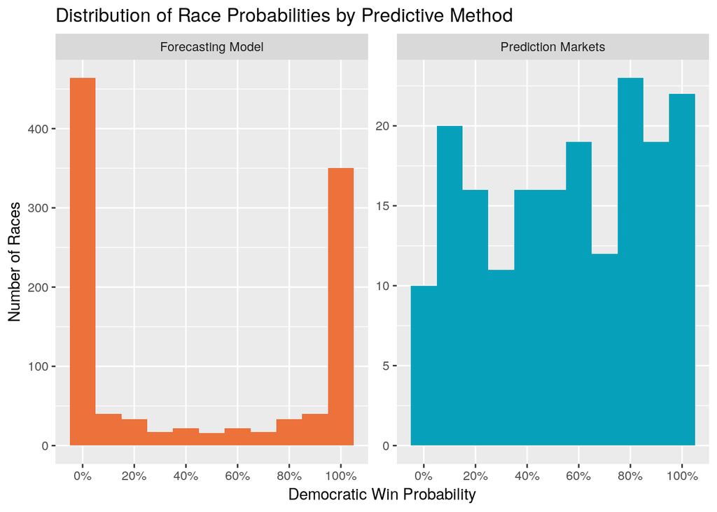

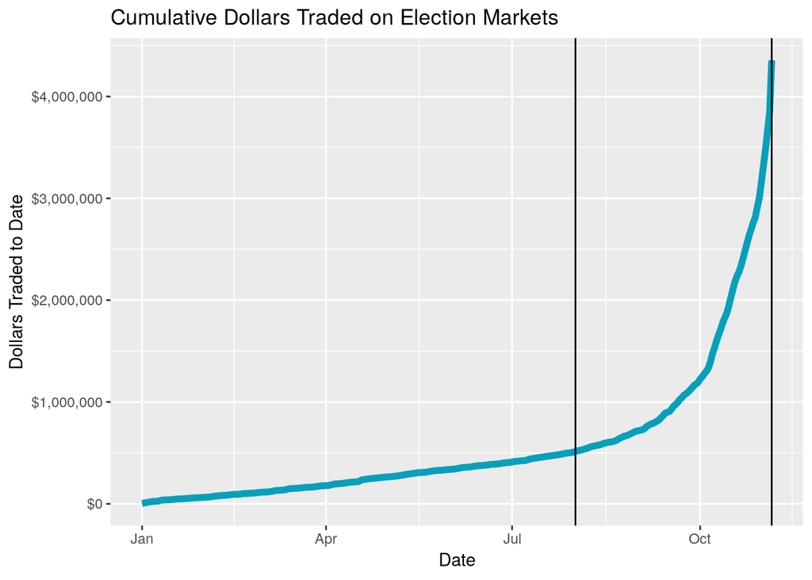

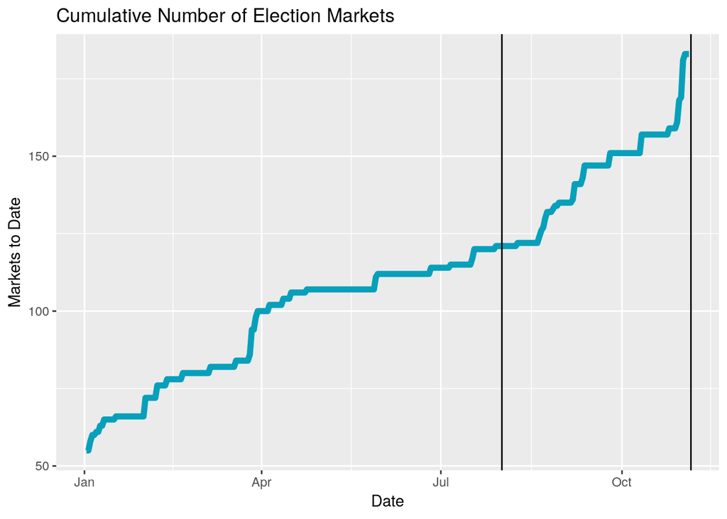

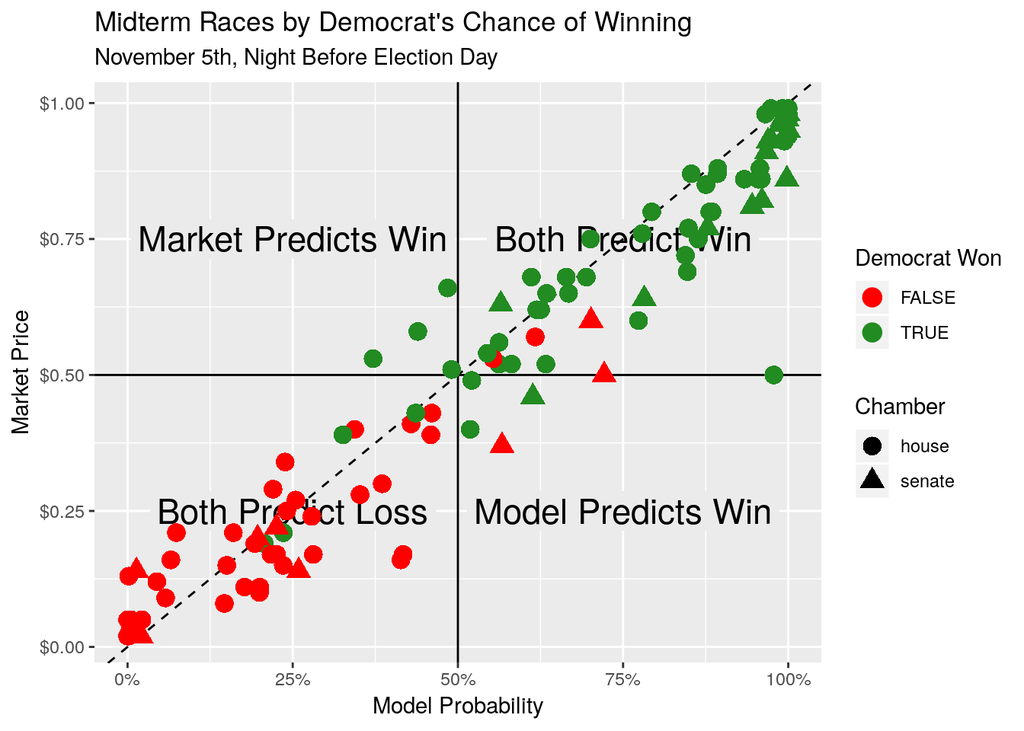

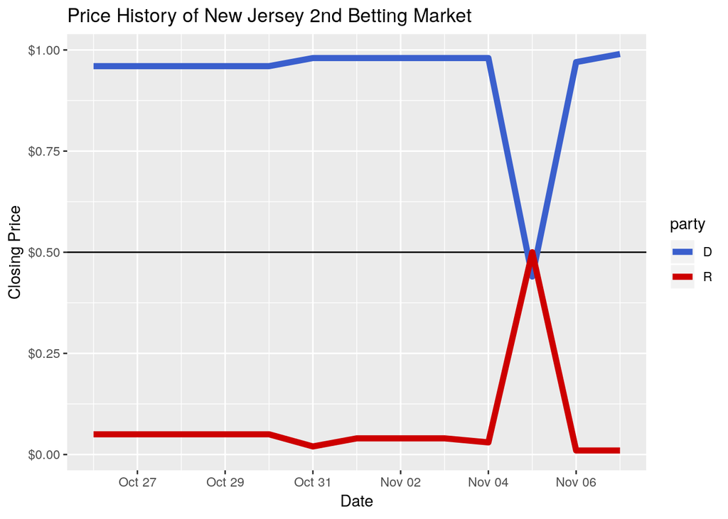

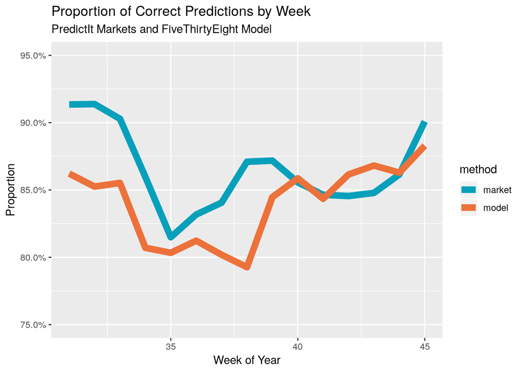

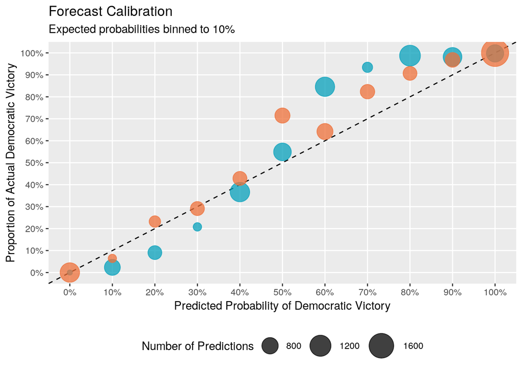

[figure not shown]

## Bibliography

Chang, Winston, Joe Cheng, JJ Allaire, Yihui Xie, and Jonathan McPherson. 2019. *Shiny: Web Application Framework for R*. https://CRAN.R-project.org/package=shiny.

FiveThirtyEight. 2018a. “House District Forecast.” https://projects.fivethirtyeight.com/2018-midterm-election-forecast/house/.

———. 2018b. “Senate Seat Forecast.” https://projects.fivethirtyeight.com/2018-midterm-election-forecast/senate/.

———. 2018c. “2018 Midterm Election Results.” https://53eig.ht/2PiFb0f.

Grolemund, Garrett, and Hadley Wickham. 2011. “Dates and Times Made Easy with lubridate.” *Journal of Statistical Software* 40 (3): 1–25. http://www.jstatsoft.org/v40/i03/.

Project, United States. 2018. “Current Legislators.” https://theunitedstates.io/congress-legislators/.

R Core Team. 2018a. *R: A Language and Environment for Statistical Computing*. Vienna, Austria: R Foundation for Statistical Computing. https://www.R-project.org/.

———. 2018b. *R: A Language and Environment for Statistical Computing*. Vienna, Austria: R Foundation for Statistical Computing. https://www.R-project.org/.

Research Applications Laboratory, NCAR -. 2015. *Verification: Weather Forecast Verification Utilities*. https://CRAN.R-project.org/package=verification.

Rudis, Bob. 2017. *Wayback: Tools to Work with Internet Archive Wayback Machine Apis*. https://github.com/hrbrmstr/wayback.

Wickham, Hadley. 2016. *Ggplot2: Elegant Graphics for Data Analysis*. Springer-Verlag New York. https://ggplot2.tidyverse.org.

———. 2019. *Stringr: Simple, Consistent Wrappers for Common String Operations*. https://CRAN.R-project.org/package=stringr.

Wickham, Hadley, and Lionel Henry. 2019. *Tidyr: Easily Tidy Data with ’Spread()’ and ’Gather()’ Functions*. https://CRAN.R-project.org/package=tidyr.

Wickham, Hadley, Jim Hester, and Romain Francois. 2018. *Readr: Read Rectangular Text Data*. https://CRAN.R-project.org/package=readr.